# Analyzing Employment and Wages Across Different Industries

### June 5

## Introduction

For this project, I wanted to better understand how employment and wages have shifted across different industries in the U.S. over time. I focused on data from the U.S. Bureau of Labor Statistics (BLS) because it provides detailed monthly statistics on employment, unemployment, and earnings by industry. The data is extensive and captures historical trends from 2006 to 2023, which allows me to explore how major economic events like the 2008 recession and the COVID-19 pandemic impacted different sectors.

What drew me to this dataset is that employment trends often reflect the broader health of the economy. I was curious to see which industries showed growth, which struggled, and how workers' earnings evolved across different time periods. My goal was to track not just how many people were working, but also whether their pay changed — and how that varied by industry.

The three main fields I focused on were:

- **Industry sector** — to see which areas of the economy were driving job creation.
- **Employment numbers** — to understand how job counts changed over time.
- **Average weekly earnings** — to evaluate whether workers’ wages were rising or stagnating.

My hypothesis was that healthcare and tech-related industries would show stronger resilience and consistent growth, while sectors like retail or manufacturing might be more sensitive to economic disruptions. I also wanted to understand whether some industries recovered faster than others after major downturns.

The population represented by this data includes nonfarm wage and salary workers across the U.S., with data collected from over 144,000 businesses and government agencies, representing around 697,000 worksites. While it’s not a full census, the CES program uses stratified sampling and weighting to ensure it captures national labor market trends accurately.

For this analysis, I used the full dataset across industry, wage, and employment dimensions. After merging and cleaning the data into a readable format, I explored trends from 2006 through 2023 to gain insight into how different parts of the job market evolved and what that says about the broader economy.

## Data Explained

### Data Source

The data comes from the [Bureau of Labor Statistics CES](https://www.bls.gov/ces). It includes employment and earnings data across various industries from 2006 to 2023.

### Data Preparation

To get the dataset ready for analysis, I did the following:

- Merged multiple CES data files using industry and data type codes.
- Dropped unnecessary columns with mostly missing values.
- Checked and removed duplicate rows (none were found).
- Identified and removed outliers using the IQR method.
- Converted the `value` column to numeric format.
- Made sure there were no missing values in important columns.
- Created a proper date column from year and month for time-based analysis.
- Removed industries with missing records
- Added a 'Sector' column to group industries for comparative analysis

### Data Dictionary

Used for Analysis based on the filtered data:`filtered_summary_ces_data.csv`

[output not shown]

## Results

```python
import pandas as pd
import matplotlib.pyplot as plt
import seaborn as sns

# Load the cleaned summary data
df = pd.read_csv("filtered_summary_ces_data.csv")

# Preview data
df.head()
```

|  | Industry | Metric | Year | Value |
| --- | --- | --- | --- | --- |
| 0 | Aerospace product and parts manufacturing | AGGREGATE WEEKLY HOURS OF ALL EMPLOYEES, THOUS... | 2006 | 20101.550000 |
| 1 | Aerospace product and parts manufacturing | AGGREGATE WEEKLY HOURS OF ALL EMPLOYEES, THOUS... | 2007 | 20885.541667 |
| 2 | Aerospace product and parts manufacturing | AGGREGATE WEEKLY HOURS OF ALL EMPLOYEES, THOUS... | 2008 | 21793.416667 |
| 3 | Aerospace product and parts manufacturing | AGGREGATE WEEKLY HOURS OF ALL EMPLOYEES, THOUS... | 2009 | 21386.583333 |
| 4 | Aerospace product and parts manufacturing | AGGREGATE WEEKLY HOURS OF ALL EMPLOYEES, THOUS... | 2010 | 20518.875000 |

### Growth Analysis Between 2006 and 2023

We calculate the absolute growth in employment and wages for each industry between 2006 and 2023 to identify top and bottom performers.

```python
# Calculate growth for employment
employment_growth = df[(df['Metric'] == 'ALL EMPLOYEES, THOUSANDS') & (df['Year'].isin([2006, 2023]))]
employment_pivot = employment_growth.pivot(index='Industry', columns='Year', values='Value').reset_index()
employment_pivot['Growth'] = employment_pivot[2023] - employment_pivot[2006]
top_employment_growth = employment_pivot.sort_values('Growth', ascending=False).head(5)
bottom_employment_growth = employment_pivot.sort_values('Growth').head(5)

# Calculate growth for wages
wage_growth = df[(df['Metric'] == 'AVERAGE WEEKLY EARNINGS OF ALL EMPLOYEES') & (df['Year'].isin([2006, 2023]))]
wage_pivot = wage_growth.pivot(index='Industry', columns='Year', values='Value').reset_index()
wage_pivot['Growth'] = wage_pivot[2023] - wage_pivot[2006]
top_wage_growth = wage_pivot.sort_values('Growth', ascending=False).head(5)
bottom_wage_growth = wage_pivot.sort_values('Growth').head(5)

# Display results
print("Top Employment Growth Industries:")
for i in top_employment_growth['Industry']:
    print(f"- {i}")

print("\nBottom Employment Growth Industries:")
for i in bottom_employment_growth['Industry']:
    print(f"- {i}")

print("\nTop Wage Growth Industries:")
for i in top_wage_growth['Industry']:
    print(f"- {i}")

print("\nBottom Wage Growth Industries:")
for i in bottom_wage_growth['Industry']:
    print(f"- {i}")
```

```
Top Employment Growth Industries:
- Computer systems design and related services
- Management, scientific, and technical consulting services
- Warehouse clubs, supercenters, and other general merchandise retailers
- Home health care services
- Offices of other health practitioners

Bottom Employment Growth Industries:
- Furniture, home furnishings, electronics, and appliance retailers
- Clothing, clothing accessories, shoe, and jewelry retailers
- Clothing and clothing accessories retailers
- Computer and electronic product manufacturing
- Furniture and related product manufacturing

Top Wage Growth Industries:
- Web search portals, libraries, archives, and other information services
- Material handling equipment manufacturing
- General medical and surgical hospitals
- Hospitals
- Electrical equipment manufacturing

Bottom Wage Growth Industries:
- Cosmetics, beauty supplies, and perfume retailers
- Office supplies and stationery retailers
- Hardware retailers
- Electronics and appliance retailers
- Other health and personal care retailers
```

### Insights

Top Employment Growth Industries show sectors that have significantly expanded their workforce, likely driven by strong demand or structural growth.

Bottom Employment Growth Industries indicate shrinking or stagnant sectors, potentially due to automation, offshoring, or declining demand.

Top Wage Growth Industries reflect sectors investing more in labor, possibly due to competition for talent or higher-value work.

Bottom Wage Growth Industries may be more vulnerable to low-wage traps, limited productivity growth, or economic pressure.

This analysis helps us pinpoint sectors that are expanding vs. those struggling in either workforce or compensation dimensions.

### Correlation Between Employment and Wage Growth

Analyzing the relationship between employment growth and wage growth can reveal whether industries are investing in workforce expansion, compensation, or both.

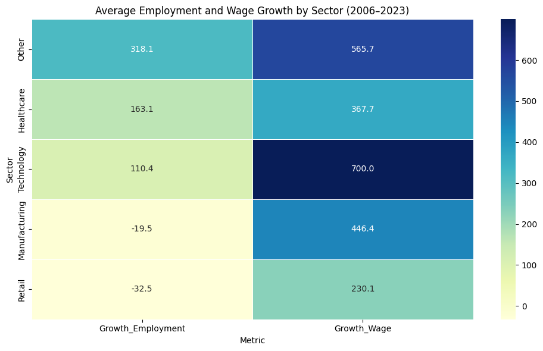

```python
import pandas as pd
import matplotlib.pyplot as plt
import seaborn as sns

# Make sure Year is integer
df['Year'] = df['Year'].astype(int)

# Step 1: Compute growth
emp = df[(df['Metric'] == 'ALL EMPLOYEES, THOUSANDS') & df['Year'].isin([2006, 2023])]
emp_pivot = emp.pivot(index='Industry', columns='Year', values='Value').reset_index()
emp_pivot['Growth_Employment'] = emp_pivot[2023] - emp_pivot[2006]

wage = df[(df['Metric'] == 'AVERAGE WEEKLY EARNINGS OF ALL EMPLOYEES') & df['Year'].isin([2006, 2023])]
wage_pivot = wage.pivot(index='Industry', columns='Year', values='Value').reset_index()
wage_pivot['Growth_Wage'] = wage_pivot[2023] - wage_pivot[2006]

# Merge and classify
merged = pd.merge(
    emp_pivot[['Industry', 'Growth_Employment']],
    wage_pivot[['Industry', 'Growth_Wage']],
    on='Industry'
)

# Sector classification
def classify_sector(industry):
    industry = industry.lower()
    if any(k in industry for k in ['hospital', 'health', 'ambulatory', 'practitioner']):
        return 'Healthcare'
    elif any(k in industry for k in ['software', 'computer', 'web search', 'technology']):
        return 'Technology'
    elif any(k in industry for k in ['retail', 'retailer']):
        return 'Retail'
    elif any(k in industry for k in ['manufactur', 'machinery', 'equipment']):
        return 'Manufacturing'
    elif any(k in industry for k in ['finance', 'insurance', 'bank']):
        return 'Finance'
    elif any(k in industry for k in ['education', 'school']):
        return 'Education'
    else:
        return 'Other'

merged['Sector'] = merged['Industry'].apply(classify_sector)
merged = merged.dropna()

# Step 2: Group by Sector and average
sector_summary = merged.groupby('Sector')[['Growth_Employment', 'Growth_Wage']].mean().sort_values(by='Growth_Employment', ascending=False)

# Step 3: Plot
plt.figure(figsize=(10, 6))
sns.heatmap(sector_summary, annot=True, fmt=".1f", cmap='YlGnBu', linewidths=.5)
plt.title("Average Employment and Wage Growth by Sector (2006–2023)")
plt.xlabel("Metric")
plt.ylabel("Sector")
plt.tight_layout()
plt.show()
```

### Insights:

> This visualization highlights how sector resilience and transformation patterns have varied significantly across the U.S. labor market between 2006 and 2023.

### Impact of Economic Events

We overlay major economic events, such as the 2008 recession and the COVID-19 pandemic, on the employment and wage trends to assess their impact on different sectors of the industries.

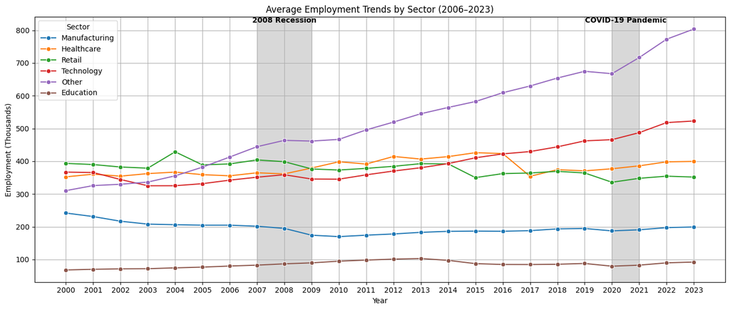

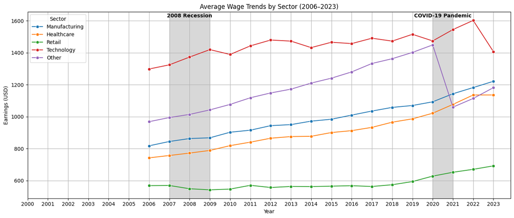

```python
import matplotlib.pyplot as plt
import seaborn as sns

# Define economic events
economic_events = {
    '2008 Recession': (2007, 2009),
    'COVID-19 Pandemic': (2020, 2021)
}

# Define sector classification to evaluate the industries in a better way.
def classify_sector(industry):
    industry = industry.lower()
    if any(k in industry for k in ['hospital', 'health', 'ambulatory', 'practitioner']):
        return 'Healthcare'
    elif any(k in industry for k in ['software', 'computer', 'web search', 'technology']):
        return 'Technology'
    elif any(k in industry for k in ['retail', 'retailer']):
        return 'Retail'
    elif any(k in industry for k in ['manufactur', 'machinery', 'equipment']):
        return 'Manufacturing'
    elif any(k in industry for k in ['finance', 'insurance', 'bank']):
        return 'Finance'
    elif any(k in industry for k in ['education', 'school']):
        return 'Education'
    else:
        return 'Other'

# Apply classification
df['Sector'] = df['Industry'].apply(classify_sector)

# Filter and clean data
employment_data = df[df['Metric'] == 'ALL EMPLOYEES, THOUSANDS'].dropna(subset=['Value'])
wage_data = df[df['Metric'] == 'AVERAGE WEEKLY EARNINGS OF ALL EMPLOYEES'].dropna(subset=['Value'])

# Plot Employment Trends
plt.figure(figsize=(14, 6))
sns.lineplot(data=employment_data, x='Year', y='Value', hue='Sector', estimator='mean', errorbar=None, marker='o')
for event, (start, end) in economic_events.items():
    plt.axvspan(start, end, color='gray', alpha=0.3)
    plt.text((start + end) / 2, plt.ylim()[1]*0.98, event, ha='center', fontsize=10, fontweight='bold')
plt.title('Average Employment Trends by Sector (2006–2023)')
plt.xlabel('Year')
plt.ylabel('Employment (Thousands)')
plt.xticks(sorted(df['Year'].unique()))
plt.grid(True)
plt.tight_layout()
plt.show()

# Plot Wage Trends
plt.figure(figsize=(14, 6))
sns.lineplot(data=wage_data, x='Year', y='Value', hue='Sector', estimator='mean', errorbar=None, marker='o')
for event, (start, end) in economic_events.items():
    plt.axvspan(start, end, color='gray', alpha=0.3)
    plt.text((start + end) / 2, plt.ylim()[1]*0.98, event, ha='center', fontsize=10, fontweight='bold')
plt.title('Average Wage Trends by Sector (2006–2023)')
plt.xlabel('Year')
plt.ylabel('Earnings (USD)')
plt.xticks(sorted(df['Year'].unique()))
plt.grid(True)
plt.tight_layout()
plt.show()
```

### Insights:

Looking at the trends from 2006 to 2023, a few clear patterns stand out, especially when comparing how different sectors responded to major economic events like the 2008 recession and the COVID-19 pandemic.

During the 2008 recession, employment in manufacturing and retail dipped slightly or plateaued, but the overall impact wasn’t dramatic. Wages in these sectors held steady or even showed gradual increases. This suggests that while some job cuts may have happened, employers likely retained key roles and avoided slashing wages, possibly due to union contracts, wage stickiness, or simply needing to keep essential operations running.

All in all, the side-by-side charts help paint a clear picture. Some sectors, especially healthcare and technology, are built to withstand shocks and keep moving forward. Others, like retail and manufacturing, feel the impact more quickly and take longer to recover. It’s a reminder that resilience in the labor market isn’t just about job counts. It’s also about how industries adapt, prioritize, and invest in their people.

## Summary

The large dataset provided was massive and very hard to ensure we look at all the different perspectives. To get to here, I had to merge the files together in different ways to get what was needed to perform the analysis. In addition to this, a few industries had incomplete or inconsistent data, especially in recent years, which made it harder to capture a full picture across the board. Also, figuring out the best way to visualize everything wasn’t always straightforward. For instance, I initially tried bubble charts, but they weren’t the clearest — switching to heatmaps worked much better for communicating comparative growth.

After exploring employment and wage trends across industries from 2006 to 2023, a few clear patterns stood out. By looking at how different sectors behaved before, during, and after major events like the 2008 recession and the COVID-19 pandemic, we were able to uncover which industries stayed strong, which ones struggled, and how workers were affected along the way.

Overall, this project helped me connect real-world labor data with broader economic shifts. It was interesting to see how different industries adapted (or didn’t) in response to major events like the recession and the pandemic, and how those choices showed up in both job counts and compensation.

Going forward, it would be great to build on this by bringing in more datasets from the same source. Adding in factors like inflation, cost of living, regional data, or demographics like age, gender, and part-time vs full-time status could help paint a more detailed picture of who was most affected and how. There’s also a lot of potential to explore forecasting models to see where things might be heading based on the patterns we’ve already seen.